# Simple linear regression

#### Question 6

How much of the variability in the outcome variable `Price` is explained by the regression equation? Comment on the $R^2$. *Hint*: `glance()`

| r.squared | adj.r.squared | sigma | statistic | p.value | df | logLik | AIC | BIC | deviance | df.residual |
| --- | --- | --- | --- | --- | --- | --- | --- | --- | --- | --- |
| 0.3569171 | 0.3498503 | 0.8364451 | 50.50586 | 2.588454e-10 | 2 | -114.3411 | 234.6822 | 242.28 | 63.66728 | 91 |

#### Question 7

Compute the sum of squared residuals. Extract the residuals using `augment()`. Match these residuals to the original data and sort the residuals. Is there manufacturers that on averages produces larger or smaller residuals? What do you notice about the residual patterns with respect to the manufacturers?

```
[1] 63.66728
```

[output not shown]

[output cut: 83 more lines]

[output not shown]

## Exploring additional variables

Below is figure showing how Price varies with EngineSize in the Cars93, with accompanying regression lines. There are two plots, one for USA cars, and one for non-USA cars.

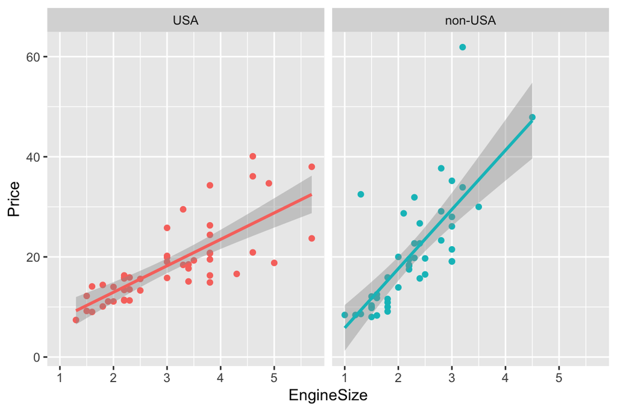